# Gradient_Boosting

1. Practice

Predicting Breast Cancer.

Import the breast cancer dataset. The data can be downloaded at this link

Set the input (X) and output (y) (Use df.columns to see all the columns to easier copy/paste). Split the data into 60% training and 40% testing

Train a gradient boosting model with 200 n_estimators and .1 learning rare. What is testing accuracy of the gradient boosting?

What is the most important variable according to the above gradient boosting model in predicting breast cancer?

Find a gradient boosting (try a few different of n_estimators and learning_rate) that have a higher testing accuracy than the above gradient boosting. What is the n_estimators and learning of this gradient boosting?

Import the breast cancer dataset. The data can be downloaded at this link

```python
# Importing libraries
import pandas as pd
import numpy as np
from sklearn import tree
from sklearn import metrics
```

```python
# Importing data and saving it to a dataframe; the first five rows are displayed with the head function.
df = pd.read_csv('breast_cancer.csv')
df.columns
```

```
Index(['id', 'diagnosis', 'radius_mean', 'texture_mean', 'perimeter_mean',
       'area_mean', 'smoothness_mean', 'compactness_mean', 'concavity_mean',
       'concave points_mean', 'symmetry_mean', 'fractal_dimension_mean',
       'radius_se', 'texture_se', 'perimeter_se', 'area_se', 'smoothness_se',
       'compactness_se', 'concavity_se', 'concave points_se', 'symmetry_se',
       'fractal_dimension_se', 'radius_worst', 'texture_worst',
       'perimeter_worst', 'area_worst', 'smoothness_worst',
       'compactness_worst', 'concavity_worst', 'concave points_worst',
       'symmetry_worst', 'fractal_dimension_worst', 'Unnamed: 32'],
      dtype='object')
```

Set the input (X) and output (y) (Use df.columns to see all the columns to easier copy/paste). Split the data into 60% training and 40% testing. Train a gradient boosting model with 200 n_estimators and .1 learning rare. What is testing accuracy of the gradient boosting?

```python
# Assign input variables

np.random.seed(42)

X = df.loc[:,['radius_worst', 'texture_worst',
       'perimeter_worst', 'area_worst', 'smoothness_worst',
       'compactness_worst', 'concavity_worst', 'concave points_worst',
       'symmetry_worst', 'fractal_dimension_worst']]

# Assign target variable
y = df['diagnosis']

# Setting Input / Output and partitioning data with a 40:60 testing:training split.
from sklearn.model_selection import train_test_split
np.random.seed(42)

x_train,x_test,y_train,y_test=train_test_split(X,y,test_size=0.40)

# Importing 'GradientBoostingClassifier' and then training the gradient boosting model.
from sklearn.ensemble import GradientBoostingClassifier
r1 = GradientBoostingClassifier(n_estimators=200, learning_rate=0.1)
r1.fit(x_train, y_train)

# Testing model and displaying performance statistics.
ypred_test = r1.predict(x_test)
from sklearn.metrics import confusion_matrix
mat = confusion_matrix(ypred_test, y_test)
print('===============')
print('Confusion Matrix:')
print(mat)
print('===============')
print('Testing Accuracy:')
print(mat.diagonal().sum()/mat.sum())
print('===============')
```

```
===============
Confusion Matrix:
[[143   5]
 [  5  75]]
===============
Testing Accuracy:
0.956140350877193
===============
```

**The testing accuracy of the first gradient boosting model is ~0.9561.

What is the most important variable according to the above gradient boosting model in predicting breast cancer?

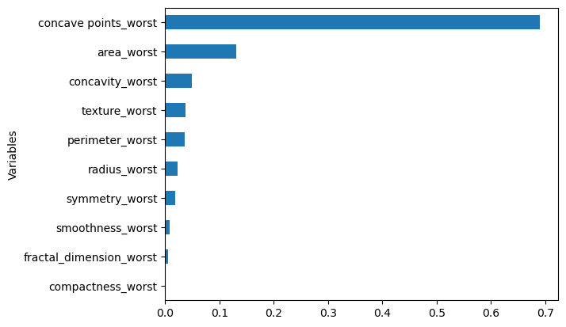

```python
# Plotting the variable importance of the model above.
import warnings
warnings.filterwarnings('ignore')

sorted_idx = (-r1.feature_importances_).argsort()

feature_importance = pd.DataFrame({'Variables':x_train.columns[sorted_idx], 'Importance':r1.feature_importances_[sorted_idx]})
df = feature_importance[:10]
df.sort_values('Importance',inplace=True)

df.plot(kind='barh',y='Importance',x='Variables', legend=False)
```

**The most important variable according to the model in terms of predicting breast cancer is `concave points_worst`.

Find a gradient boosting (try a few different of n_estimators and learning_rate) that have a higher testing accuracy than the above gradient boosting. What is the n_estimators and learning of this gradient boosting?

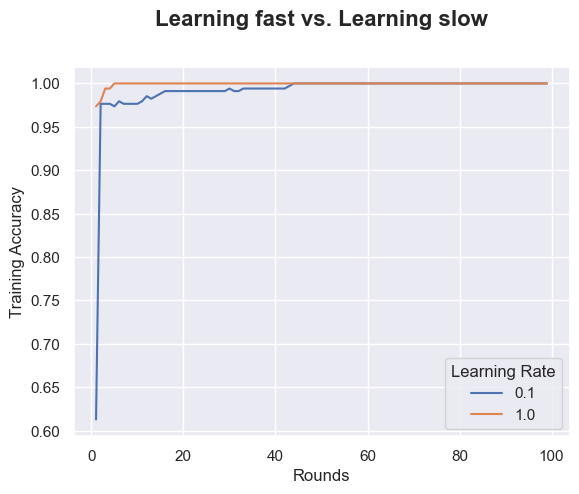

```python
# Plot the Training Accuracy of gradient boosting with n_estimators running from n1 to n2
# and two learning rates l1 and l2.
np.random.seed(42)

n1 = 1
n2 = 100
l1 = .1
l2 = 1

ac = pd.DataFrame([], columns=list(['Rounds','Learning Rate','Accuracy']))
from sklearn.tree import DecisionTreeClassifier
for rs in range(n1, n2):
    for lr in [l1, l2]:
        boost = GradientBoostingClassifier(n_estimators=rs, learning_rate=lr)
        boost.fit(x_train,y_train)
        ac = pd.concat([ac, pd.DataFrame([[rs, lr, boost.score(x_train,y_train)]],
                                    columns=list(['Rounds','Learning Rate','Training Accuracy']))],
                       ignore_index=True)


import seaborn as sns; sns.set()
import matplotlib.pyplot as plt
ax = sns.lineplot(x="Rounds", y="Training Accuracy",
                  hue =ac['Learning Rate'].astype('category'),data=ac)
ax.text(x=0.5, y=1.1, s='Learning fast vs. Learning slow',
        fontsize=16, weight='bold', ha='center', va='bottom', transform=ax.transAxes)
```

```python
# Training the gradient boosting model with the optimal hyper parameters found from the previous cell.

r1 = GradientBoostingClassifier(n_estimators=20, learning_rate=1)
r1.fit(x_train, y_train)

# Testing model and displaying performance statistics.
ypred_test = r1.predict(x_test)
from sklearn.metrics import confusion_matrix
mat = confusion_matrix(ypred_test, y_test)
print('===============')
print('Confusion Matrix:')
print(mat)
print('===============')
print('Testing Accuracy:')
print(mat.diagonal().sum()/mat.sum())
print('===============')
```

```
===============
Confusion Matrix:
[[145   5]
 [  3  75]]
===============
Testing Accuracy:
0.9649122807017544
===============
```

The testing accuracy and final hyper parameters for the model are:

Testing Accuracy = 0.9649

n_estimators = 20

learning_rate = 1